# Data Science for Public Policy

Assignment04

Author

Lingxi Li - ll1188, Talia Stringfellow -tjs296

## Research question

Energy transformation stands as a pivotal element in the global response to climate change. Following the establishment of the Kyoto Protocol in 1997, the international community has increasingly prioritized the reduction of carbon emissions and the pivot towards sustainable energy practices. This commitment was further underscored by the adoption of the Paris Agreement in 2015, marking a renewed global consensus on the critical importance of energy policy in the fight against climate change.

Amidst this backdrop, our research delves into the energy sector’s evolution from 2010 to 2018, with a particular emphasis on the BRICS nations—Brazil, Russia, India, China, and South Africa. As leading economies among developing countries, the BRICS bloc represents a significant intersection of rapid economic growth and environmental stewardship. Their energy policies and practices are not only central to their sustainable development agendas but also carry profound implications for global climate change mitigation efforts.

In our examination of energy modalities, we place a particular emphasis on electricity due to its significant role as one of the foremost contributors to global carbon emissions. As highlighted by the United Nations, “most electricity continues to be produced through the combustion of fossil fuels; however, there is a noticeable shift towards cleaner energy sources.” This focus underscores the pivotal transition needed within the energy sector.

By analyzing energy data from Our World Data, we aim to uncover trends toward more sustainable energy usage within these nations, analyzing how they are practically addressing climate change.

## Data resource

We refer to the energy data set from Our World In Data to analyze the question. The resource link is: https://ourworldindata.org/explorers/energy

## Clean the data

We focus on the energy data of the BRICS nations from 2010 to 2018.

```r
library(tidyverse)
data<-read_csv("data/energy_data.csv")
data<-data %>%
  filter(country=="China"|country=="Brazil"|country=="Russia"|country=="India"|country=="South Africa",
         year>=2010 & year<=2018)
```

## BRICS’s total electricity generation as a share of primary energy between 2010 and 2018

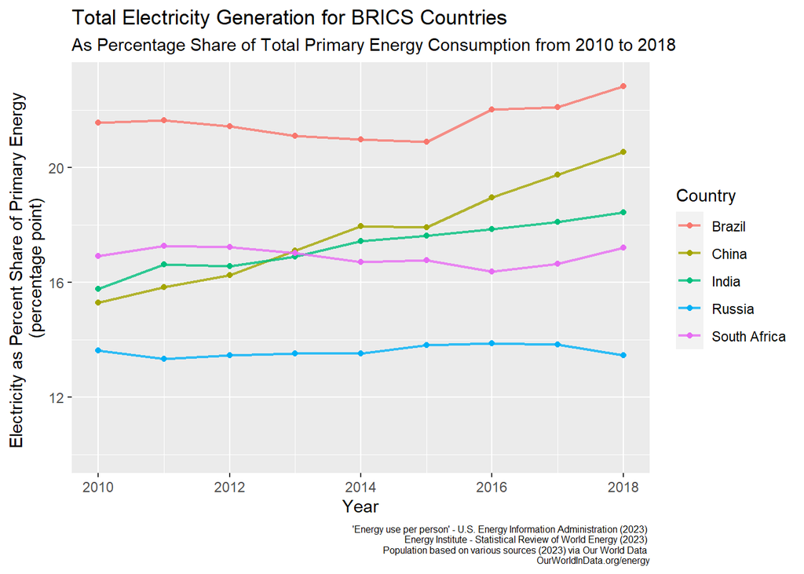

```r
library(ggplot2)
data %>%
  ggplot(aes(x = year, y= electricity_share_energy))+
  geom_line(aes(color=(country)),alpha=0.8,size=0.8)+
  geom_point(aes(color=(country)))+
  scale_y_continuous(limit=c(10,23))+
  theme_grey()+
  theme(plot.caption = element_text(size = 6)) +
  labs(x = "Year", y = "Electricity as Percent Share of Primary Energy \n(percentage point)",
       title = "Total Electricity Generation for BRICS Countries",
       subtitle = "As Percentage Share of Total Primary Energy Consumption from 2010 to 2018",
       caption="'Energy use per person' - U.S. Energy Information Administration (2023) \n Energy Institute - Statistical Review of World Energy (2023) \n Population based on various sources (2023) via Our World Data \n OurWorldInData.org/energy") +
  scale_color_discrete(name = "Country")
```

This data is interesting to contextualize the question of electricity energy as a share of each country’s energy usage, but we will dive deeper into the subsequent graphs.

## BRICS electricity demand from 2010 to 2018

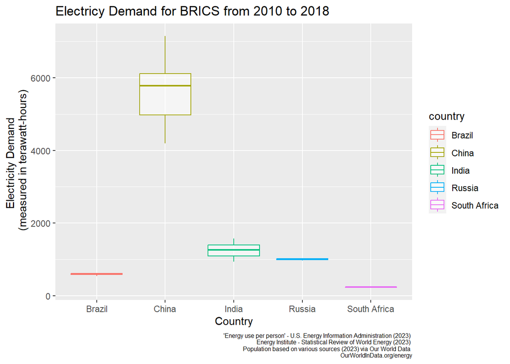

```r
data %>%
ggplot(aes(x=country,y=electricity_demand))+
  geom_boxplot(aes(color=country),alpha=0.5,linewidth=0.4)+
  theme_grey()+
  theme(plot.caption = element_text(size = 6))+
  labs(x = "Country", y = "Electricity Demand \n (measured in terawatt-hours)",
       title = "Electricy Demand for BRICS from 2010 to 2018",
       caption="'Energy use per person' - U.S. Energy Information Administration (2023) \n Energy Institute - Statistical Review of World Energy (2023) \n Population based on various sources (2023) via Our World Data \n OurWorldInData.org/energy")
```

## BRICS’s carbon intensity change between 2010 and 2018

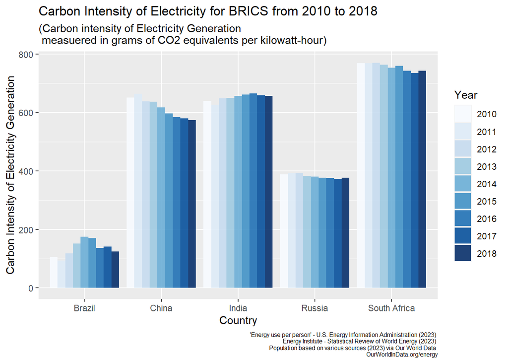

```r
data %>%
ggplot(aes(x = country, y = carbon_intensity_elec,fill = factor(year))) +
  geom_bar(stat = "identity", position = "dodge", alpha=0.9)+
  scale_fill_brewer(palette = "Blues")+
  theme_grey()+
  theme(plot.caption = element_text(size = 6))+
  labs(x = "Country",
       y = "Carbon Intensity of Electricity Generation", fill = "Year",
       title="Carbon Intensity of Electricity for BRICS from 2010 to 2018",
       subtitle="(Carbon intensity of Electricity Generation \n measuered in grams of CO2 equivalents per kilowatt-hour)",
       caption="'Energy use per person' - U.S. Energy Information Administration (2023) \n Energy Institute - Statistical Review of World Energy (2023) \n Population based on various sources (2023) via Our World Data \n OurWorldInData.org/energy")
```

Moreover, the nine-year range allows us to observe long-term change. Brazil reached a peak in 2014 and we observe a steady decline starting in 2015. In China, the peak is in 2011 followed by a steady decrease. This pattern is also observable in South Africa, though with a less linear decline. Russia remains stagnant. India has a somewhat consistent, though rising, overall trend in CO₂ equivalents per kilowatt-hour. Post-2015, we expected that the intensity of carbon for electricity generation would decrease as they invest in renewable resources for generating electricity but the observable change is minimal.

## How BRICS’s carbon intensity changed with its electricity import from 2010 to 2018

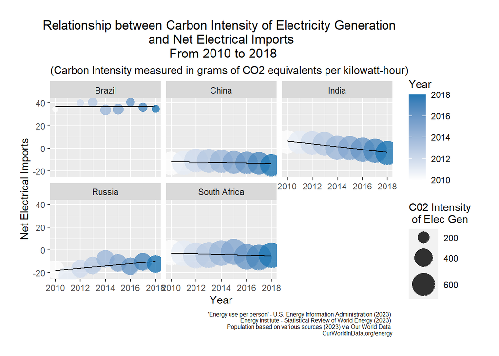

```r
data %>%
  group_by(country) %>%
  ggplot(aes(x = year, y= net_elec_imports)) +
  geom_point(aes(size=carbon_intensity_elec,color=year),alpha=0.8) +
  geom_smooth(method="lm", se=F, linewidth=0.5, color="black")+
  facet_wrap(~country)+
  labs(x = "Year", y = "Net Electrical Imports",
       title = "Relationship between Carbon Intensity of Electricity Generation \n and Net Electrical Imports \n From 2010 to 2018",
       subtitle = "(Carbon Intensity measured in grams of CO2 equivalents per kilowatt-hour)",
       color = "Year", caption="'Energy use per person' - U.S. Energy Information Administration (2023) \n Energy Institute - Statistical Review of World Energy (2023) \n Population based on various sources (2023) via Our World Data \n OurWorldInData.org/energy") +
  theme_grey()+
  theme(plot.title = element_text(hjust = 0.5),
        plot.margin = margin(t = 20, r = 20, b = 20, l = 20),
        plot.caption = element_text(size = 6))+
  scale_size_continuous(name = "C02 Intensity \n of Elec Gen",range=c(1,12))+
  scale_color_gradient(low = "#FEFEFE", high = "#1f77b4")
```

Here we observe the relationship between net electricity imports on the carbon intensity of electricity generation. As we expected, countries that import more than they export in electricity have lower carbon intensity of electricity generation - as the generated carbon is occurring outside the nation. Brazil fluctuates below the 250 grams of CO₂ equivalents per kilowatt-hour carbon intensity of electricity generation. Interestingly, the variance in CO2 intensity of electrical generation remains consistent across the 8-year within the remaining 4 BRICS nations. China stagnates at exporting just slightly more than imports and consistent levels of CO2 equivalence. This trend is also seen in South Africa, though with more variation between years and relative to China, more CO2 equivalence. In Russia, we observe a pattern of increasing reliance on imports over exports, though they remain negative in their net electrical imports. Conversely, India since 2010 has changed from positive net electoral imports to negative in 2018 via a steady downward trajectory.

## Reference

Sources Cited: Brics: What is the group and which countries have joined? (2024, February 1). BBC. https://www.bbc.com/news/world-66525474

Nations, U. (n.d.). Generating power. United Nations; United Nations. https://www.un.org/en/climatechange/climate-solutions/cities-pollution

Data Source: ‘Energy use per person’ - U.S. Energy Information Administration (2023) Energy Institute - Statistical Review of World Energy (2023) Population based on various sources (2023) via Our World Data OurWorldInData.org/energy